# **Week 3: Logistic Regression**

## Data at a glance

#### The original Datasets:

The data-set used here is based on the datasets provided by the [UCI Machine Learning Repository](https://archive.ics.uci.edu/ml/datasets/Student+Performance).

Citation of the dataset-reference: *P. Cortez and A. Silva. Using Data Mining to Predict Secondary School Student Performance. In A. Brito and J. Teixeira Eds., Proceedings of 5th FUture BUsiness TEChnology Conference (FUBUTEC 2008) pp. 5-12, Porto, Portugal, April, 2008, EUROSIS, ISBN 978-9077381-39-7.*

The original datasets “student_mat.csv” (including 395 observations and 33 variables, with regard to the subject of mathematics) and “student_por.csv” (consisting of 649 observations and 33 variables, relating to the subject of Portuguese) were established from data collected at two Portuguese secondary schools.

The data attributes of these original datasets include student grades, demographic, social and school related features) and it was collected by using school reports and questionnaires.

The age range of the respondents lies between 15 and 22 years.

The three final variables “G1”, “G2”, and “G3” relate to the specific grades the respondent has achieved either in mathematics or in Portuguese, while the other variables operationalize more general conditions of the respective respondent, relating to his or her familial background, school- and leisure-time habits, and general information (i.e., for instance, age and gender).

#### The altered dataset used in this project:

In order to look at my data-wrangling coding for this week’s exercise, feel free to [go this way](https://github.com/JoaWe/IODS-project/blob/master/data/create_alc.R).

The two datasets were joined by means of using the variables “school”, “sex”, “age”, “address”, “famsize”, “Pstatus”, “Medu”, “Fedu”, “Mjob”, “Fjob”, “reason”, “nursery”,“internet” as identifiers. Only the respondents present in both datasets were kept for the newly established dataset.

Two new variables, “alc_use” and “high_use”, have been established in the new dataset, by the following means:

1.**alc_use**: The average of the answers related to weekday and weekend alcohol consumption have been taken.

2.**high_use**: Then the newly created variable “alc_use” has been utilized to create a second new variable “high_use”, which is TRUE for students for whom “alc_use”" is greater than 2.

Accordingly, this new dataset now contains **382 observations relating to 35 variables**.

- Reading the joined student alcohol-consumption data into R from my data-folder:

```r
alc <- read.csv("C:\\Users\\Ani\\Documents\\GitHub\\IODS-project\\data\\alc.csv", header=TRUE)
```

- structure of my data-set:

```r
str(alc)
```

```
## 'data.frame':    382 obs. of  35 variables:
##  $ school    : Factor w/ 2 levels "GP","MS": 1 1 1 1 1 1 1 1 1 1 ...
##  $ sex       : Factor w/ 2 levels "F","M": 1 1 1 1 1 2 2 1 2 2 ...
##  $ age       : int  18 17 15 15 16 16 16 17 15 15 ...
##  $ address   : Factor w/ 2 levels "R","U": 2 2 2 2 2 2 2 2 2 2 ...
##  $ famsize   : Factor w/ 2 levels "GT3","LE3": 1 1 2 1 1 2 2 1 2 1 ...
##  $ Pstatus   : Factor w/ 2 levels "A","T": 1 2 2 2 2 2 2 1 1 2 ...
##  $ Medu      : int  4 1 1 4 3 4 2 4 3 3 ...
##  $ Fedu      : int  4 1 1 2 3 3 2 4 2 4 ...
##  $ Mjob      : Factor w/ 5 levels "at_home","health",..: 1 1 1 2 3 4 3 3 4 3 ...
##  $ Fjob      : Factor w/ 5 levels "at_home","health",..: 5 3 3 4 3 3 3 5 3 3 ...
##  $ reason    : Factor w/ 4 levels "course","home",..: 1 1 3 2 2 4 2 2 2 2 ...
##  $ nursery   : Factor w/ 2 levels "no","yes": 2 1 2 2 2 2 2 2 2 2 ...
##  $ internet  : Factor w/ 2 levels "no","yes": 1 2 2 2 1 2 2 1 2 2 ...
##  $ guardian  : Factor w/ 3 levels "father","mother",..: 2 1 2 2 1 2 2 2 2 2 ...
```

[output cut: 21 more lines]

- the dimensions of the dataset:

```r
dim(alc)
```

```
## [1] 382  35
```

An interesting inside into the newly established dataset is provided by looking at the summary of the variable “sex”:

```r
summary(alc$sex)
```

```
##   F   M
## 198 184
```

It makes clear that, while the gender-representation of the respondents may not be an exact 50% of the total number of respondents, it does come sufficiantly close (~52% of the respondents are female). This information may come in useeful in the further analysis.

## Hypotheses relating to students’ alcohol-consumption

Accessing libraries:

```r
library(tidyr)
library(dplyr)
```

```r
library(ggplot2)
```

#### General explanations with regard to the alcohol-consumption variables

With regard to higher or lower alcohol-consumption among students certain hypotheses can be presumed relating to the following **four variables** taken from the newly established dataset “alc.csv”. These hypotheses are to be tested and (dis-)proven here. The dependent variables of interest are…

…**“alc_use”**, which displays the average-answers related to weekday and weekend alcohol consumption (from 1 = very low consumption to 5 = very high consumption) . For a brief glimpse at the respective variable, see the barplot here:

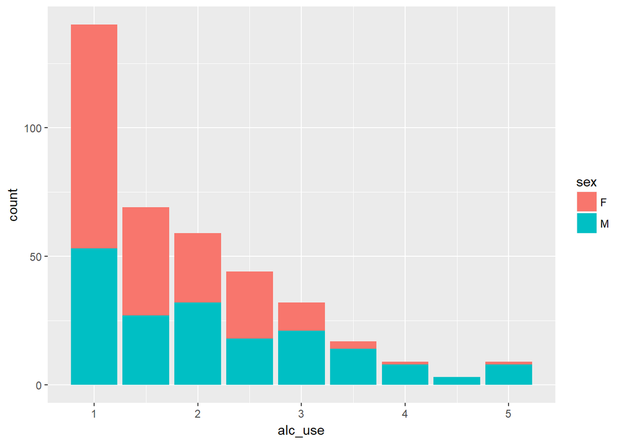

```r
g1 <- ggplot(data = alc, aes(x = alc_use, fill = sex))

g1 + geom_bar()
```

*This plot shows that the majority of the questionaires’ respondents claim to have a very low alcohol-consumption level. It also shows that particularly the majority of the female respondents sees themselves consuming very low to medium levels of alcohol. The variable is, however, a combination based on the averages of the respondents’ answers to the actual questions of weekday- and weekend-consumption of alcohol. Accordingly, generalizations have to be treated with care.*

…and **“high_use”**, which is a logical column based on the variable *“alc_use”*. High usage of alcohol-consumption is therein defined as being TRUE, if the observation in the alc_use-variable is greater than 2. Take a sneak-peak at the summary of this variable:

```r
summary(alc$high_use)
```

```
##    Mode   FALSE    TRUE
## logical     268     114
```

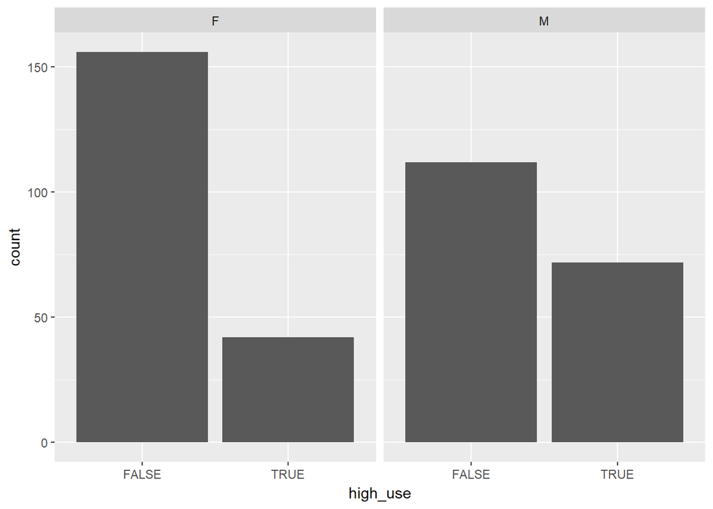

```r
g2 <- ggplot(alc, aes(high_use))

g2 + facet_wrap("sex") + geom_bar()
```

*For the interpretation of this bar-plot it needs to be remembered that the variable “high_use” is a logical column. Similar to the variable “alc_use” it was not directly answered by the respondents. The barplot shows that the majorities of both male and female respondents supposedly consume alcohol on low levels.*

##### 1. Hypothesis:

It can be assumed that a respective student’s ambitions can impact on his or her alcohol consumption habits. Accordingly, it is hypothesized that there is a negative correlation between the students’ alcohol-consumption and their interest in pursuing a higher education degree.

```r
summary(alc$higher)
```

```
##  no yes
##  18 364
```

An interesting observation at this point is that only 18 out of the 382 respondents of this dataset are *not* interested in achieving a higher educational degree.

- creating a boxplot:

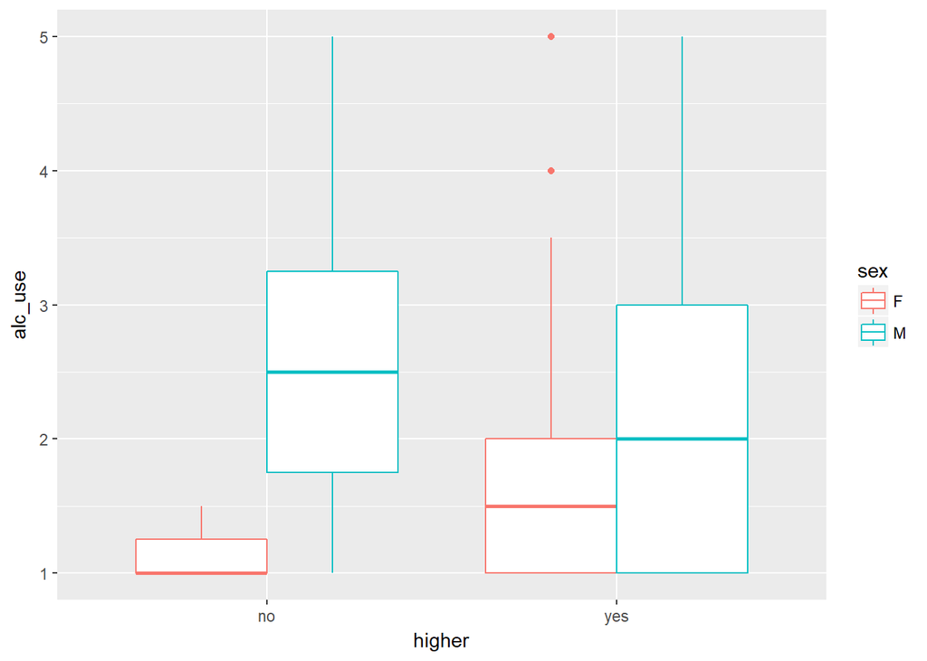

```r
library(gmodels)
g3 <- ggplot(alc, aes(x = higher, y = alc_use))
g3 <- ggplot(alc, aes(x = higher, y = alc_use, col = sex))
g3 + geom_boxplot()
```

**Observations & Interpretation:**

The boxplot is set up to visualize the potential relation between the variables of “higher” and “alc_use”, it includes the distinction of the respondents by gender.

With the exception of the box, representing the male respondents without higher education (HE) ambitions, the first quartiles start at 1 (meaning very low use of alcohol). A whisker towards the minimum is only displayed with that box (male, “no” for HE ambitions). Upwards whiskers towards the respective maximums are present on all boxes. The box for female respondents with HE-ambitions also contains two exceptions above the maximums. On both male-respondent boxes no exceptions are displayed.  
In the case of the female respondents without HE-ambitions it appears that the median lies in the same position as the 1. quartile. The responses of female students appear to be lying generally in the lower levels than those of their male equivalents. According to the boxplots, the female responses are lying below or equal to the male responses’ medians.

It appears to be very interesting to me that the female “no” (to HE) respondents in relative terms appear to be consuming the least amounts of alcohol. WHich in their case speaks against the clichee. None of the groups, however, display a consistent excessive amount of alcohol-consumption.

A point that needs to be made, however – and I apologize, if it appears to be a repition – that the variable “alc_use” represents the average of two other variables. Averages disguise, for instance extreme exceptions within the mass of observations, similarly, exceptions can raise or lower the averages. Accordingly, these results need to be viewed with care.

Furthermore, the questions relating to alcohol-consumption are answered subjectively by the respondents. And – as my hypotheses may indicate – certain stereotyping with regard to alcohol consumption are undertaken in society, which may result in a certain bias at the point, when the question is answered may be contained in the data.

##### 2. Hypothesis:

Presuming, that the time a student has to spare, impacts on his or her alcohol-consumption level, two variables are considered to be of interest:

[output not shown]

```r
summary(alc$studytime)
```

```
##    Min. 1st Qu.  Median    Mean 3rd Qu.    Max.
##   1.000   1.000   2.000   2.037   2.000   4.000
```

```r
summary(alc$activities)
```

```
##  no yes
## 181 201
```

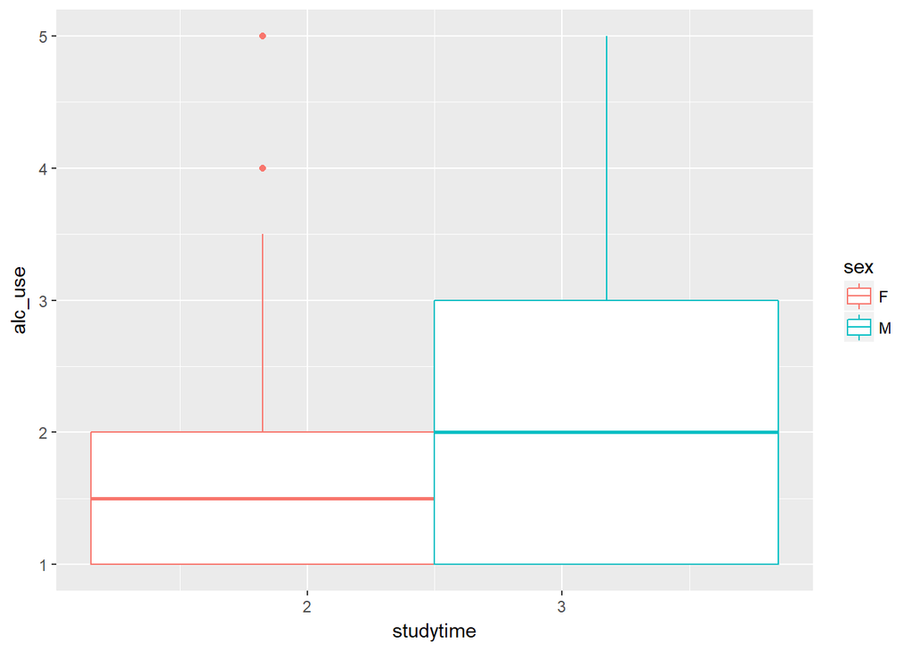

```r
library(ggplot2)

g4 <- ggplot(alc, aes(x = studytime, y = alc_use, col = sex))

g4 + geom_boxplot()
```

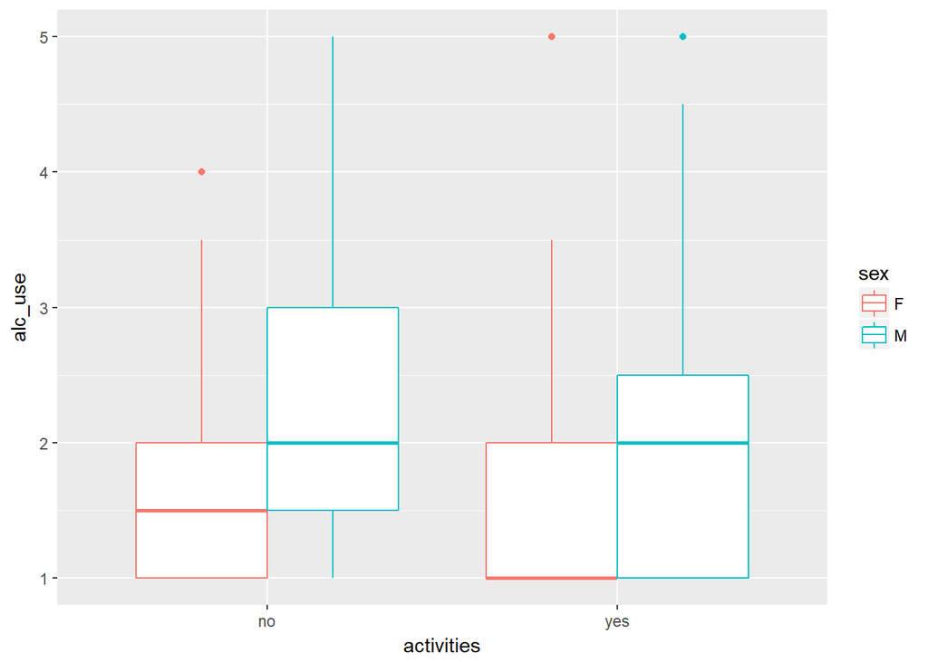

```r
g5 <- ggplot(alc, aes (x = activities, y = alc_use, col = sex))
g5 + geom_boxplot()
```

##### 3. Hypothesis:

The final assumption, to be tested here, concerns whether the familial background, can be considered to play any role in the students’ alcohol-consumption habits. There are several variables included in the dataset that could be drawn on for this hypothesis (e.g.: “famsize”, “Medu”, or “Fedu”):

[output not shown]